# Análisis Multivariado - Clase 12

2025-10-29

## Clustering

## Algoritmos de clustering

- Algoritmos de clustering:
  - Generan automáticamente particiones de observaciones.
  - Agrupan observaciones por similitud.
  - Separan observaciones por disimilitud.
    - Variables cuantitativas: Funciones de distancia.

Para utilizar un algoritmo de clustering, hay que definir tres cuestiones:

1. Las variables de interés.
2. La distancia entre observaciones.
3. El criterio para separarlas.

Todas estas características son muy ambiguas y cada una de ellas tiene una gran variedad de opciones. Por lo tanto, la cantidad de combinaciones para considerar es vasta.

## k-Medias

k-Medias es un algoritmo heurístico muy popular por su bajo costo computacional.

Se basa en cambiar iterativamente la asignación de cada grupo y se calcula en cada paso el promedio de cada grupo.

## Ejemplo

Mostraremos un ejemplo basado en los siguientes datos:

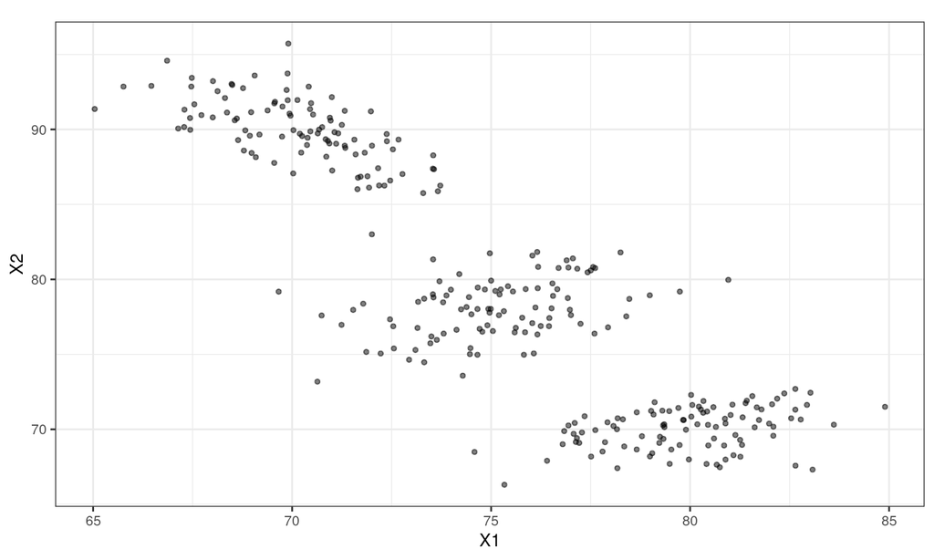

Claramente, se visualizan 3 grupos, pero el algoritmo esto no lo sabe.

## Inicialización

El algoritmo inicia asignando un grupo aleatorio a cada observación

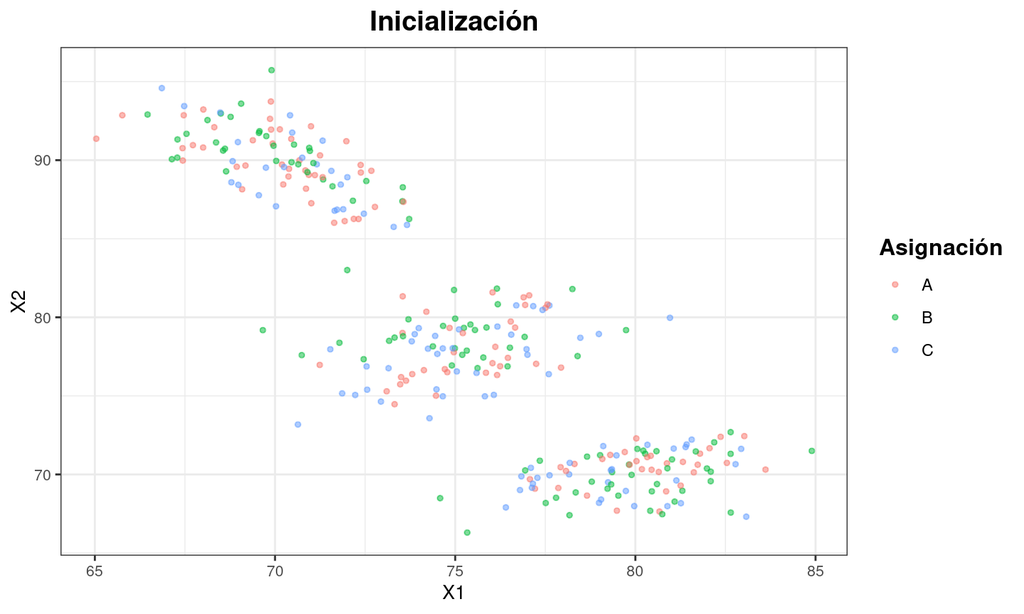

## Promedios

A partir de esta configuración inicial, se calculan los vectores promedios de cada grupo:

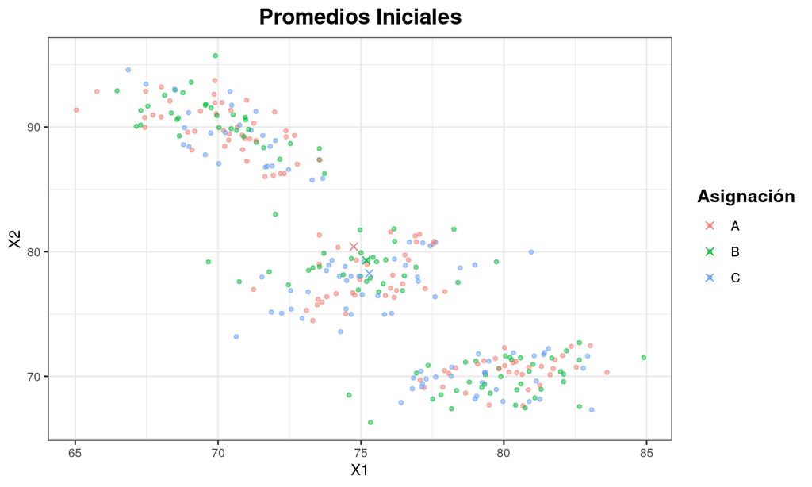

## Actualización asignaciones

Luego, se cambian las asignaciones de cada observación, al promedio que resulta más cercano:

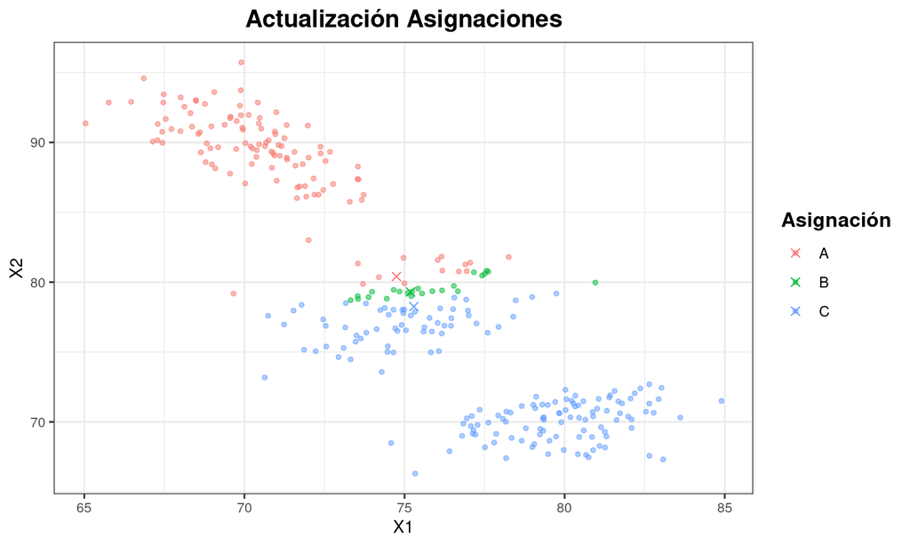

## Actualización promedios

Luego, se vuelven a calcular los promedios en cada grupo:

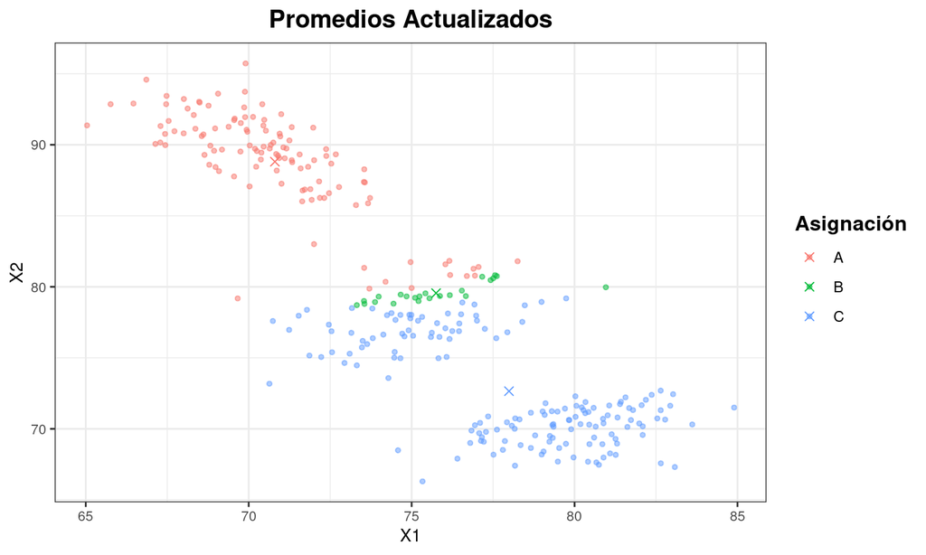

## Actualización asignaciones

Luego, se cambian las asignaciones de cada observación, al promedio que resulta más cercano:

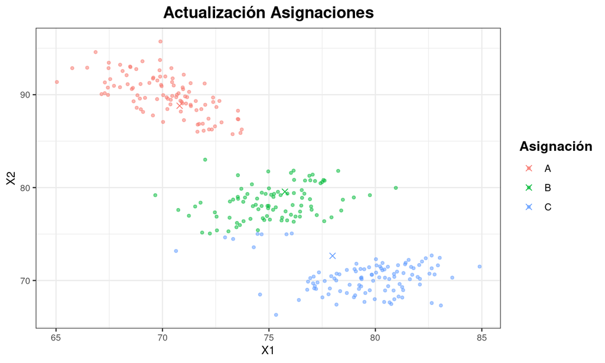

## Actualización promedios

Luego, se vuelven a calcular los promedios en cada grupo:

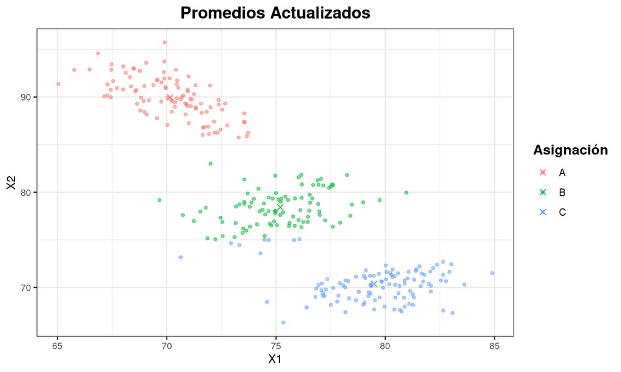

## Actualización asignaciones

Luego, se cambian las asignaciones de cada observación, al promedio que resulta más cercano:

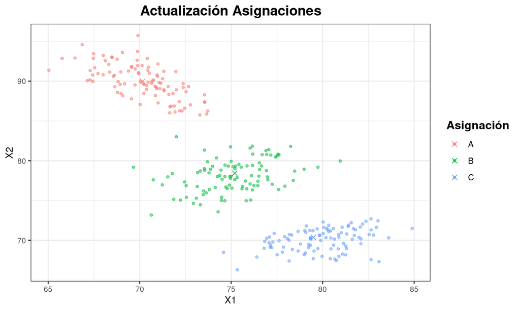

## Actualización promedios

Luego, se vuelven a calcular los promedios en cada grupo. Luego de este momento, cuando se vuelve a iterar, se obtienen los mismos grupos. Por lo tanto, se detiene el algoritmo:

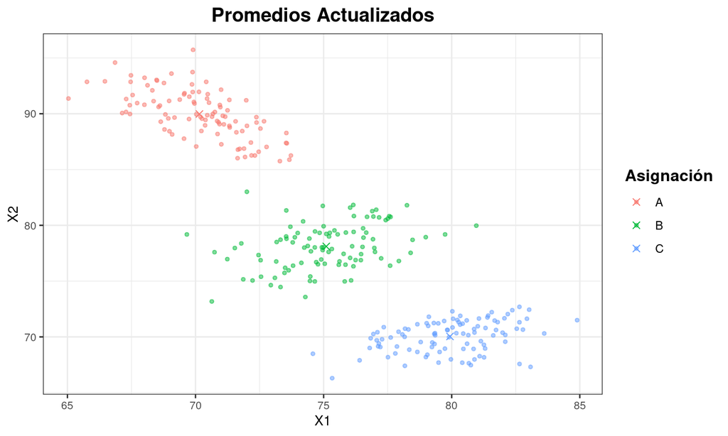

## Sensibilidad

Uno de los mayores problemas de k-Medias es que el promedio es muy sensible a datos atípicos. Por ejemplo, apliquémoslo al siguiente conjunto de datos:

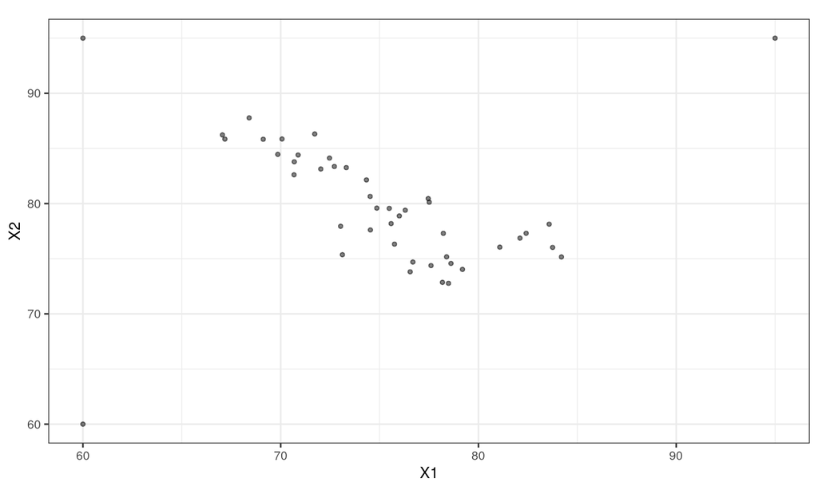

## Resultado

Vemos en el resultado final, que los promedios están muy influidos por los datos atípicos.

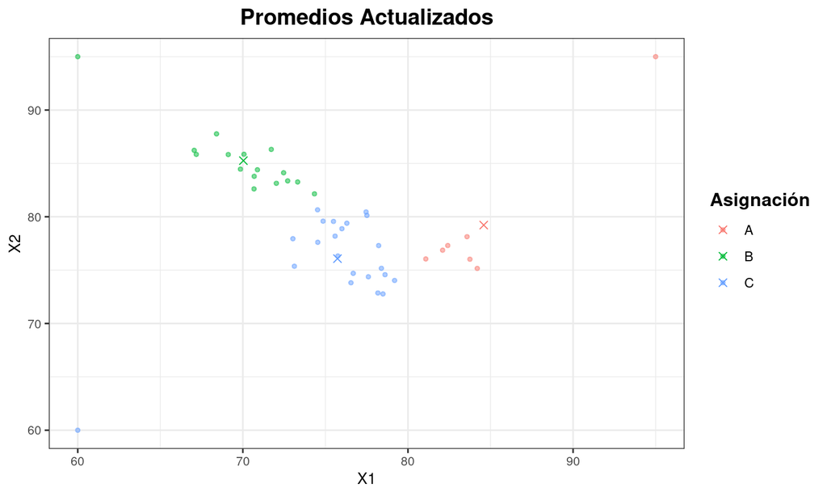

## Separabilidad

A veces, los grupos no son fáciles de separar. Por ejemplo, consideremos los siguientes datos:

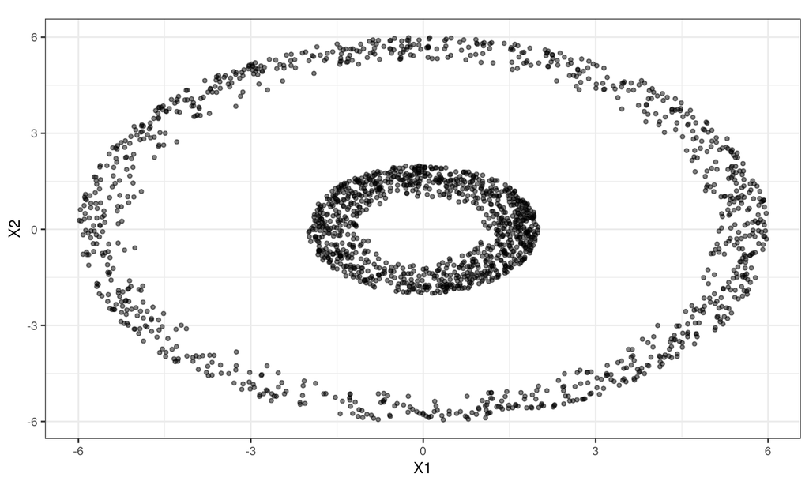

## k-Medias en datos no separables

Aplicar k-Medias a este conjunto de datos da el siguiente resultado:

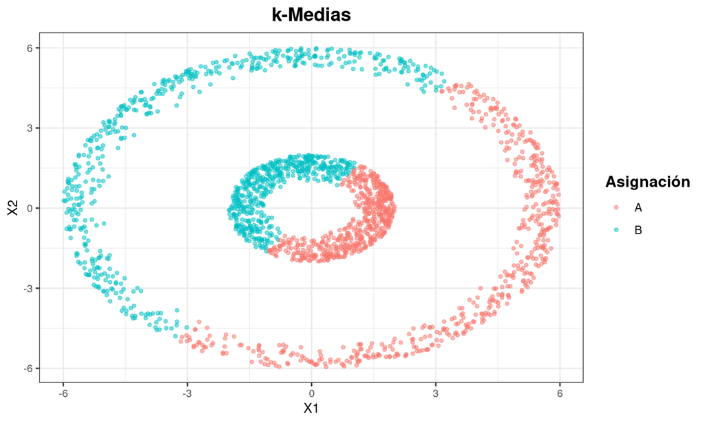

Vemos que no logra separarlo en ambos grupos

## Utilización de Kernels

La idea del k-Medias basado en Kernels es que se busca transformar los datos para obtener los grupos linealmente separables. Es decir, se busca una función \(\phi\) para que los resultados queden en un espacio de mayor dimensión, y se aplica \(k\)-Medias en un espacio de mayor dimensión.

Si bien realizar el algoritmo en este nuevo espacio puede ser costoso, la distancia entre observaciones se puede vincular con una Función de Kernel que simplifica el cálculo.

En general, se puede usar la función de Kernel Radial: \[K(\vec{x}_i,\vec{x}_j)=e^{-\frac{||\vec{x}_i-\vec{x}_j||^2}{2\cdot \sigma^2}}\] Donde \(\sigma\) es un parámetro que se determina de antemano, aunque a veces se puede buscar de forma automática.

## Resultados con k-Medias basado en Kernels

Con este Kernel, se obtienen los resultados deseados:

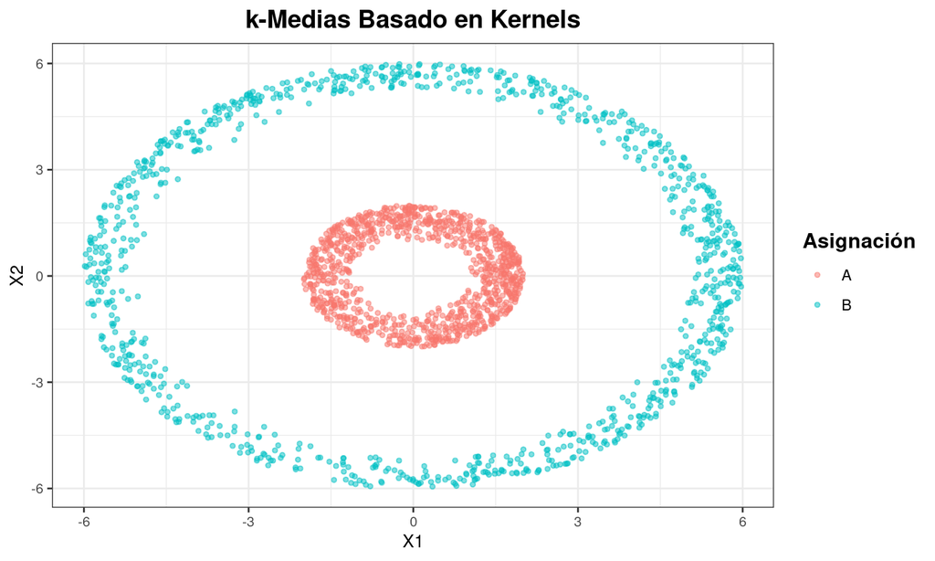

## Datos longitudinales

Supongamos que tenemos las siguientes evoluciones de PBI en distintos países a través de los años:

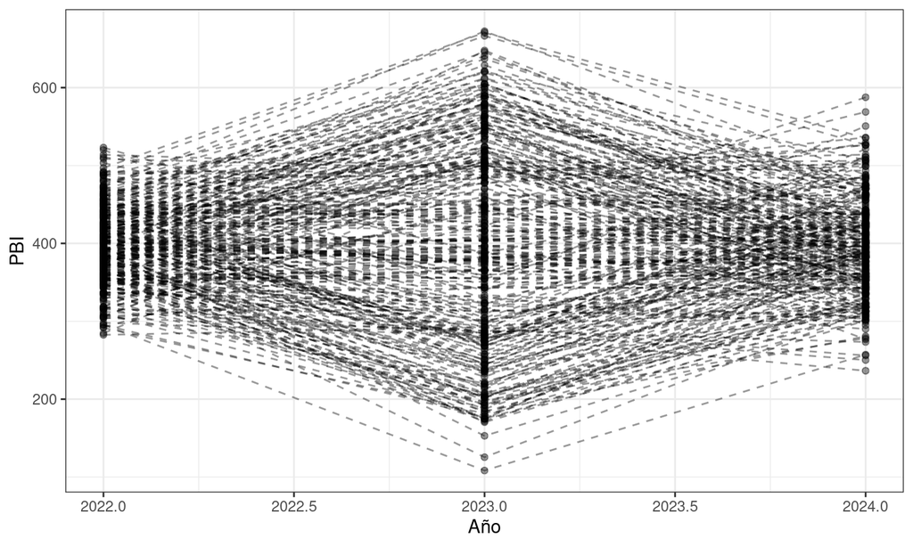

## Clustering

Pareciera haber comportamientos similares, algunos países cuyo PBI sube y baja, otros donde baja y sube, y otros donde se mantiene estable. Si se quisiera aplicar un clustering de estas trayectorias, vemos que no logra capturar las similitudes deseadas:

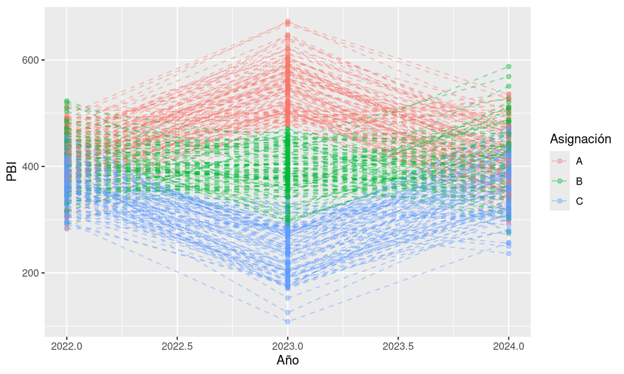

## Espacio de las pendientes

Si en vez de analizar los **valores** del PBI, consideramos las **variaciones** en PBI, obtenemos lo siguiente:

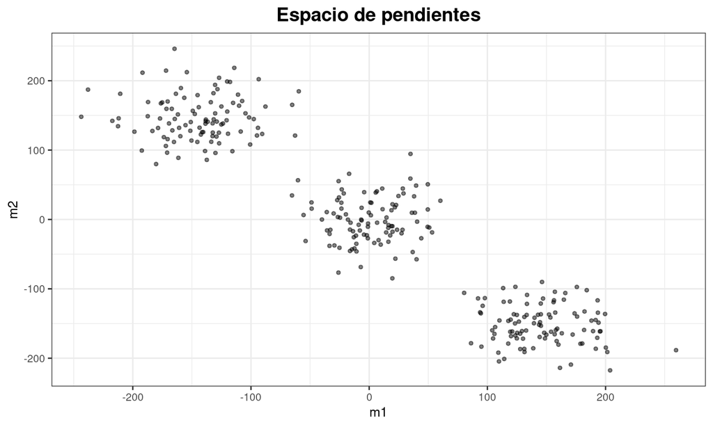

Vemos que en este espacio se observan grupos bien definidos.

## Clustering por valores

De hecho, aquí vemos los resultados del clustering anterior aplicado a este espacio:

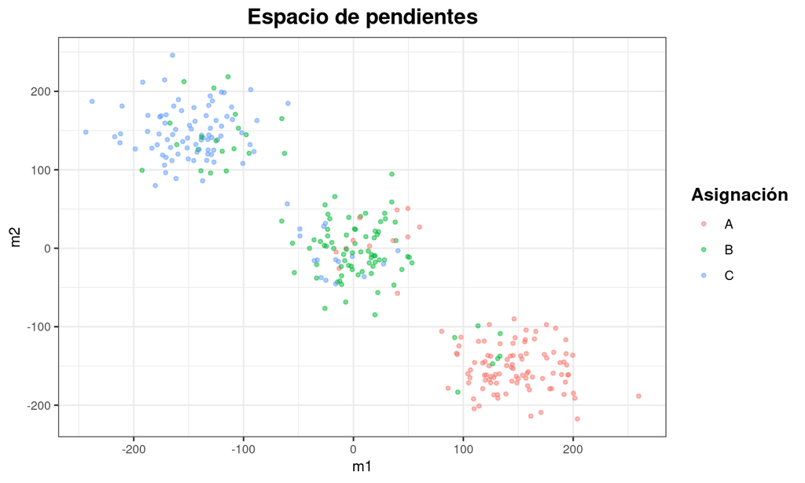

## Clustering por variación

Aplicando el algoritmo de clustering en este espacio, se obtiene la división deseada:

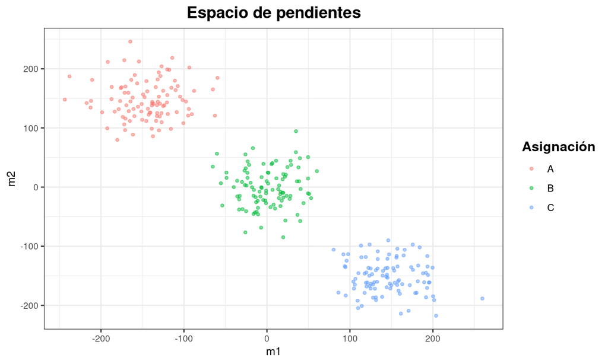

## Trayectorias agrupadas por variación

Estos resultados vemos que no se ven influidas por la cercanía de las trayectorias, sino que respetan las variaciones:

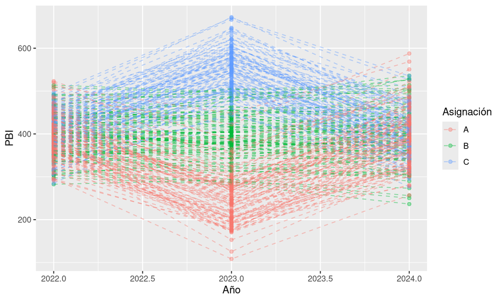

## Dimensión alta

En varias dimensiones es muy difícil visualizar grupos:

```
##          Matemática   Física  Química Literatura Historia
## Juan       82.57296 73.71835 79.24807   76.81157 90.56891
## Lucas      70.79069 71.97067 76.68448   86.54011 78.72417
## Emanuel    70.76964 86.51110 85.25077   70.15597 90.10950
## Catalina   73.63782 73.55069 75.49362   82.21224 80.21975
## Martín     77.81357 78.56761 81.56164   71.54595 89.32747
## Sofía      77.09474 72.96771 75.30148   72.19256 79.57865
```

```
##          Economía Filosofía   Inglés Geografía Biología
## Juan     83.85196  68.88103 87.84928  89.72490 77.82571
## Lucas    79.81478  73.94472 71.05361  87.53680 77.09555
## Emanuel  82.18182  85.70722 85.28429  84.67025 77.38458
## Catalina 79.35098  73.15487 69.08728  86.65059 84.87531
## Martín   69.54651  84.04608 78.75986  83.27666 82.06470
## Sofía    77.83372  81.38680 68.48428  85.78499 76.34795
```

## Multidimensional scaling

Utilizando la reducción de dimensionalidad MDS, podemos ver que estos datos conviene agruparlos en 3 grupos.

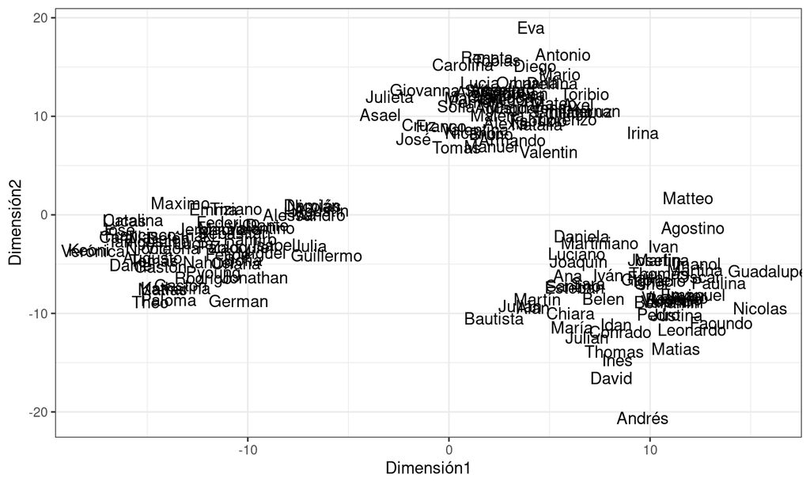

## Criterios de calidad

- **Criterios de calidad:** Evalúan los resultados obtenidos por un algoritmo de clustering.
  - **Criterios Internos:** Buscan propiedades deseables en una partición.
  - **Criterios Externos:** Buscan concordancia de una partición con una partición de referencia.

## Concordancia

La mayor dificultad para medir concordancia entre dos particiones es que aunque las etiquetas sean distintas, las particiones pueden ser similares. Más aún, se puede ver en el siguiente ejemplo que ambas particiones pueden ser iguales:

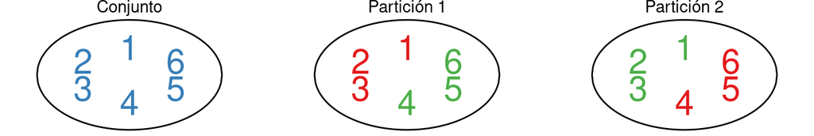

## Concordancia

Por lo tanto, las medidas de concordancia se basan en los pares de observaciones, viendo si pertenecen al mismo grupo (se nota como \(y\)) o no (se nota como \(n\)) en ambas particiones. Usaremos el siguiente ejemplo:

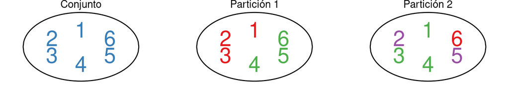

\[\tiny \begin{array}{c|cccccccc} & \{1,2\}& \{1,3\}& \{1,4\}& \{1,5\}& \{1,6\}& \{2,3\} & \{2,4\}& \{2,5\}\\ \hline \text{Partición 1} & y &y &n &n &n &y &n &n \\ \text{Partición 2} &n &y &y &n &n &n &n &y \end{array} \] \[\tiny \begin{array}{c|ccccccc} & \{2,6\}& \{3,4\}& \{3,5\}& \{3,6\} & \{4,5\}& \{4,6\}& \{5,6\}\\ \hline \text{Partición 1} & n &n &n &n &y &y &y \\ \text{Partición 2} &n &y &n &n &n &n &n \end{array} \]

## Concordancia

Mientras más pares presenten la misma pertenencia, mayor será será la concordancia entre las particiones.

\[\tiny \begin{array}{c|cccccccc} & \{1,2\}& \{1,3\}& \{1,4\}& \{1,5\}& \{1,6\}& \{2,3\} & \{2,4\}& \{2,5\}\\ \hline \text{Partición 1} & y &y &n &n &n &y &n &n \\ \text{Partición 2} &n &y &y &n &n &n &n &y \end{array} \] \[\tiny \begin{array}{c|ccccccc} & \{2,6\}& \{3,4\}& \{3,5\}& \{3,6\} & \{4,5\}& \{4,6\}& \{5,6\}\\ \hline \text{Partición 1} & n &n &n &n &y &y &y \\ \text{Partición 2} &n &y &n &n &n &n &n \end{array} \]

En este caso, se registran las siguientes magnitudes: \(yy=1\), \(yn=5\), \(ny=3\), \(nn=6\). Estos 4 valores son los que se usan en los criterios externos.

## Criterios externos

Hacemos foco en los siguientes criterios externos:

- **Precisión (P):** \(C_P=\dfrac{yy}{yy+ny}\).
- **Recall (RC):** \(C_{Re}=\dfrac{yy}{yy+yn}\).
- **Folkes-Mallows (FM):** \(C_{FM}=\dfrac{yy}{\sqrt{(yy+yn)\cdot (yy+ny)} }\).
- **Kulczynski (K):** \(C_{K}=\dfrac{1}{2}\cdot\left( \dfrac{yy}{yy+ny}+\dfrac{yy}{yy+yn} \right)\).

Notar que para todos estos criterios, en casos de concordancia perfecta (\(yn=ny=0\)), los índices alcanzan un valor máximo de 1.

## Aplicación

```
## [1] "Clustering por trayectorias:"
```

```
##      folkes_mallows kulczynski precision    recall
## [1,]      0.6992364  0.6992366 0.6987425 0.6997306
```

```
## [1] "Clustering por pendientes:"
```

```
##      folkes_mallows kulczynski precision recall
## [1,]              1          1         1      1
```